# Day 3 code

Author

Constantin Manuel Bosancianu

Published

January 22, 2021

# 1 Introduction

We start in the same way as yesterday - by loading needed packages, and reading in the data.

```r
library(pacman)
p_load(tidyverse, broom, ggeffects, texreg, arm,
       broom.mixed, ggthemes, nlme, HLMdiag, knitr)
```

We will work on two data sources today, each with its own characteristics.

# 2 Sleep study

The first data set comes from a sleep study by Belenky et al. (2003). A number of 66 volunteers were subjected to sleep deprivation in varying doses over 10 days. In our analyses here we concentrate on the 18 subjects who slept only 3 hours per night for 7 days. All subjects were allowed a period of recovery of 3 days of normal sleep (8 hours a night) following the 7 days.

Throughout the 10 days ($7 \times 3$ hours per night, $3 \times 8$ hours per night) their reaction times were tested on a psychomotor vigilance test (a visual stimulus would be displayed and the subject’s reaction time to it was measured).

The data is already made available in the `lme4` package, so all we need to do it load it from there.

```r
data("sleepstudy")

sleepstudy %>%
    glimpse()
```

```
Rows: 180
Columns: 3
$ Reaction <dbl> 249.5600, 258.7047, 250.8006, 321.4398, 356.8519, 414.6901, 3…
$ Days     <dbl> 0, 1, 2, 3, 4, 5, 6, 7, 8, 9, 0, 1, 2, 3, 4, 5, 6, 7, 8, 9, 0…
$ Subject  <fct> 308, 308, 308, 308, 308, 308, 308, 308, 308, 308, 309, 309, 3…
```

We’ll only use this data for basic graphical examinations, and to test very simple “unconditional means” and “unconditional growth” models. Little more is possible, as there are no predictors to be found in the data.

The great benefit of working with smaller data sets is that we can rely more on graphical tools - these are vital in the context of longitudinal modeling in helping us understand the trajectories of change. The fact that the sleep study data only has 18 respondents is a big advantage in allowing us to keep the plots manageable in size.

Start with a *lowess* fit, to let the data speak for itself.

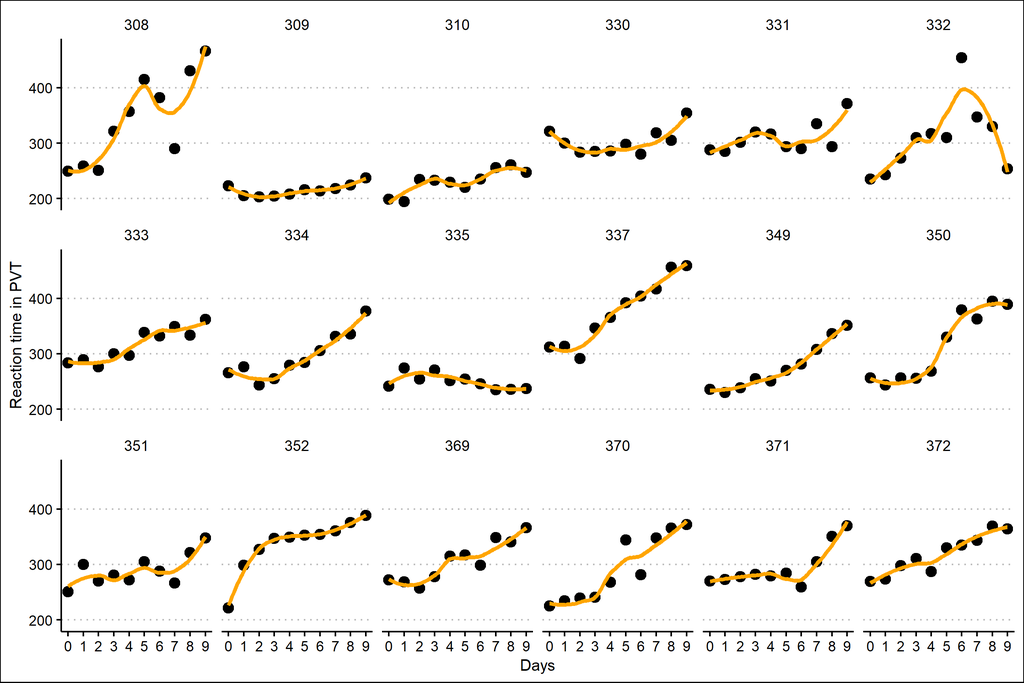

```r
ggplot(data = sleepstudy,
       aes(x = Days,
           y = Reaction)) +
  theme_clean() +
  geom_point(size = 3) +
  geom_smooth(method = "loess",
              linewidth = 1.25,
              color = "orange",
              se = FALSE) +
  facet_wrap(. ~ Subject, ncol = 6) +
  labs(x = "Days",
       y = "Reaction time in PVT") +
  scale_x_continuous(breaks = c(0, 1, 2, 3, 4,
                                5, 6, 7, 8, 9),
                     labels = c("0", "1", "2",
                                "3", "4", "5",
                                "6", "7", "8", "9"))
```

Try a linear fit as well, that imposes much more structure on the data.

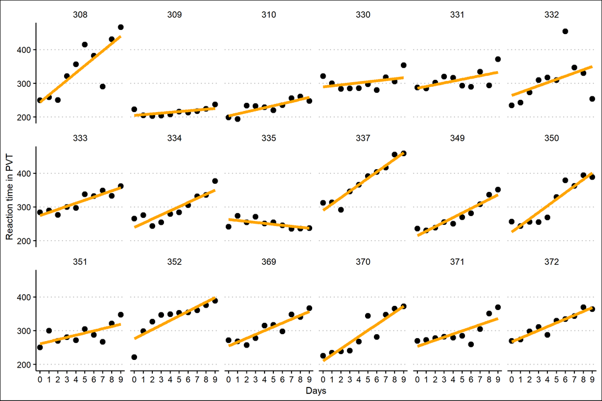

```r
ggplot(data = sleepstudy,
       aes(x = Days,
           y = Reaction)) +
    theme_clean() +
    geom_point(size = 2.5) +
    geom_smooth(method = "lm",
                size = 1.5,
                color = "orange",
                se = FALSE) +
    facet_wrap(.~Subject, ncol = 6) +
    labs(x = "Days",
         y = "Reaction time in PVT") +
    scale_x_continuous(breaks = c(0, 1, 2, 3, 4,
                                  5, 6, 7, 8, 9),
                       labels = c("0", "1", "2",
                                  "3", "4", "5",
                                  "6", "7", "8", "9"))
```

**Quick task**: Can you use a snipped of code I was using when plotting varying slopes, and display on each panel the average response time in the entire cohort of 18 subjects? (a horizontal line, that could be dashed, or have a specific color to distinguish it)[^1]

<sup>1</sup> If you want to look at one possible solution, activate the code chunk below.

```r
ggplot(data = sleepstudy,
       aes(x = Days,
           y = Reaction)) +
  theme_clean() +
  geom_point(size = 2.5) +
  geom_smooth(method = "lm",
              size = 1.5,
              color = "orange",
              se = FALSE) +
  geom_hline(yintercept = mean(sleepstudy$Reaction),
             linewidth = 1.25,
             color = "blue") +
  facet_wrap(. ~ Subject, ncol = 6) +
  labs(x = "Days",
       y = "Reaction time in PVT")
```

We can create a similar plot, but plotting the average response time in the cohort *by day*.[^2]

<sup>2</sup> As before, if you want to see a possible solution, activate the code chunk below.

```r
sleepstudy <- sleepstudy %>%
  group_by(Days) %>%
  mutate(ave_resp = mean(Reaction, na.rm = TRUE))

ggplot(data = sleepstudy,
       aes(x = Days,
           y = Reaction)) +
  theme_clean() +
  geom_point(size = 2.5) +
  geom_point(aes(x = Days,
                 y = ave_resp),
             color = "blue",
             size = 1.5) +
  geom_smooth(method = "lm",
              size = 1.5,
              color = "orange",
              se = FALSE) +
  facet_wrap(.~Subject, ncol = 6) +
  labs(x = "Days",
       y = "Reaction time in PVT")
```

## 2.1 Unconditional means specification

Visually, we can tell there’s a lot of variation across the 10 days of the experiment. Can we also get a measure of how much within-individual variation exists, as a share of total variation?

For this, we need the **unconditional means** specification. I continue the estimation as we did so far, in the `lme4` package, though this will only get us this far today.

```r
mlm.0 <- lmer(Reaction ~ 1 + (1 | Subject),
              data = sleepstudy)
summary(mlm.0)
```

```
Linear mixed model fit by REML ['lmerMod']
Formula: Reaction ~ 1 + (1 | Subject)
   Data: sleepstudy

REML criterion at convergence: 1904.3

Scaled residuals:
    Min      1Q  Median      3Q     Max
-2.4983 -0.5501 -0.1476  0.5123  3.3446

Random effects:
 Groups   Name        Variance Std.Dev.
 Subject  (Intercept) 1278     35.75
 Residual             1959     44.26
Number of obs: 180, groups:  Subject, 18

Fixed effects:
            Estimate Std. Error t value
(Intercept)   298.51       9.05   32.98
```

We can also compute an ICC based on this model.

```r
1278/(1278 + 1959)
```

```
[1] 0.39481
```

How do you interpret the ICC in the context of a longitudinal growth model?

## 2.2 Unconditional growth specification

Let’s move to the **unconditional growth** model. This is going to formalize what the first plot told us: (1) how do the initial score and rate of change in the response time change for individuals, but also (2) what the average baseline score and rate of change is in the sample.

```r
mlm.1 <- lmer(Reaction ~ 1 + Days + (1 + Days | Subject),
              data = sleepstudy)
summary(mlm.1)
```

```
Linear mixed model fit by REML ['lmerMod']
Formula: Reaction ~ 1 + Days + (1 + Days | Subject)
   Data: sleepstudy

REML criterion at convergence: 1743.6

Scaled residuals:
    Min      1Q  Median      3Q     Max
-3.9536 -0.4634  0.0231  0.4634  5.1793

Random effects:
 Groups   Name        Variance Std.Dev. Corr
 Subject  (Intercept) 612.10   24.741
          Days         35.07    5.922   0.07
 Residual             654.94   25.592
Number of obs: 180, groups:  Subject, 18

Fixed effects:
            Estimate Std. Error t value
(Intercept)  251.405      6.825  36.838
Days          10.467      1.546   6.771

Correlation of Fixed Effects:
     (Intr)
Days -0.138
```

A few questions about these results:

1. What is the average baseline response time in the sample on the first day of the experiment?
2. What’s the average rate of change in this response time for the sample?

**Quick task**: Can you plot how the estimated rate of growth varies for each individual in the sample?[^3]

<sup>3</sup> Use the code I used in the past few days to plot varying slopes between countries.

## 2.3 Examining residuals

How do the residuals look in this model? The function `hlm_resid()` extracts the residuals and predicted values from the model, and appends them to the model data frame.

```r
mlm.1.res <- hlm_resid(mlm.1,
                       level = 1)
```

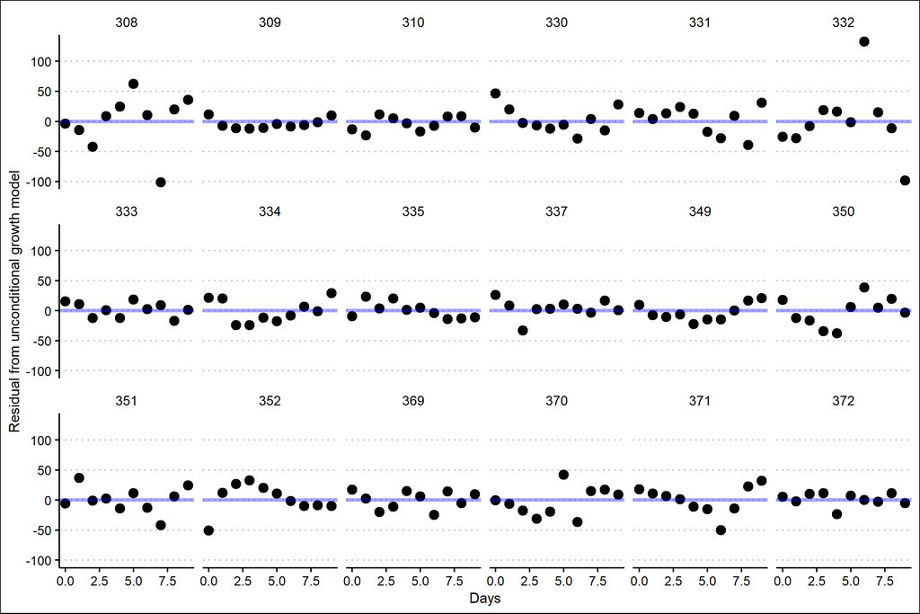

```r
ggplot(data = mlm.1.res,
       aes(x = Days,
           y = .resid)) +
    theme_clean() +
    geom_point(size = 3) +
    geom_hline(yintercept = 0,
               color = "blue",
               linewidth = 1.25,
               alpha = 0.35) +
    facet_wrap(.~Subject, ncol = 6) +
    labs(x = "Days",
         y = "Residual from unconditional growth model")
```

```r
rm(mlm.1.res)
```

The errors seem to exhibit a AR pattern to them. Sadly, we can’t do much about it in `lme4`, as the ability to specify a custom variance-covariance structure for the L1 errors is not really available. The current principal developer on the package, Ben Bolker, walks through a few of the workarounds here (https://bbolker.github.io/mixedmodels-misc/notes/corr_braindump.html), but I can’t say either option from there is truly satisfactory for us.